# Final Project CIS 544

Ana Pacella

#Installing packages needed

```r
install.packages("tidyverse")
install.packages("caTools")
install.packages("class")
install.packages("gmodels")
install.packages("stringr")
```

```
Error in install.packages : Updating loaded packages
```

```r
install.packages("tidyverse")
```

#Loading libraries

```r
library(tidyverse)
library(caTools)
library(class)
library(gmodels)
library(stringr)
library(tidyverse)
library(corrplot)
library(Metrics)
library(olsrr)
```

#Importing the data that we will be analyzing and getting a summary with glimpse

```r
imdb <- read.csv("imdb_top_1000_1.csv", stringsAsFactors = T)
glimpse(imdb)
```

```
Rows: 714
Columns: 16
$ Poster_Link   <fct> "https://m.media-amazon.com/images/M/MV5BMDFkYTc0MGEtZmNhMC00ZDIzLWFmNTEtODM1ZmRlYWMwMWFmXkEyXk…
$ Series_Title  <fct> "The Shawshank Redemption", "The Godfather", "The Dark Knight", "The Godfather: Part II", "12 A…
$ Released_Year <int> 1994, 1972, 2008, 1974, 1957, 2003, 1994, 1993, 2010, 1999, 2001, 1994, 1966, 2002, 1999, 1990,…
$ Certificate   <fct> A, A, UA, A, U, U, A, A, UA, A, U, UA, A, UA, A, A, UA, A, A, UA, A, U, R, A, U, A, A, UA, U, A…
$ Runtime..min. <int> 142, 175, 152, 202, 96, 201, 154, 195, 148, 139, 178, 142, 161, 179, 136, 146, 124, 133, 132, 1…
$ Genre         <fct> "Drama", "Crime, Drama", "Action, Crime, Drama", "Crime, Drama", "Crime, Drama", "Action, Adven…
$ IMDB_Rating   <dbl> 9.3, 9.2, 9.0, 9.0, 9.0, 8.9, 8.9, 8.9, 8.8, 8.8, 8.8, 8.8, 8.8, 8.7, 8.7, 8.7, 8.7, 8.7, 8.6, …
$ Overview      <fct> "Two imprisoned men bond over a number of years, finding solace and eventual redemption through…
$ Meta_score    <int> 80, 100, 84, 90, 96, 94, 94, 94, 74, 66, 92, 82, 90, 87, 73, 90, 82, 83, 96, 74, 79, 96, 91, 61…
$ Director      <fct> Frank Darabont, Francis Ford Coppola, Christopher Nolan, Francis Ford Coppola, Sidney Lumet, Pe…
$ Star1         <fct> Tim Robbins, Marlon Brando, Christian Bale, Al Pacino, Henry Fonda, Elijah Wood, John Travolta,…
$ Star2         <fct> Morgan Freeman, Al Pacino, Heath Ledger, Robert De Niro, Lee J. Cobb, Viggo Mortensen, Uma Thur…
$ Star3         <fct> Bob Gunton, James Caan, Aaron Eckhart, Robert Duvall, Martin Balsam, Ian McKellen, Samuel L. Ja…
$ Star4         <fct> William Sadler, Diane Keaton, Michael Caine, Diane Keaton, John Fiedler, Orlando Bloom, Bruce W…
$ No_of_Votes   <int> 2343110, 1620367, 2303232, 1129952, 689845, 1642758, 1826188, 1213505, 2067042, 1854740, 166148…
$ Gross         <int> 28341469, 134966411, 534858444, 57300000, 4360000, 377845905, 107928762, 96898818, 292576195, 3…
```

#Exploring the data - we want to get to know a sense of the data by getting its summary, head, and viewing it on a table. #Also, we are plotting two relevant variables from the data to see if they have any relation.

```r
summary(imdb$Meta_score)
```

```
   Min. 1st Qu.  Median    Mean 3rd Qu.    Max.
  28.00   70.00   78.00   77.16   86.00  100.00
```

```r
head(imdb)
```

|  | Poster_Link | Series_Title | Released_Year | Certificate | Runtime..min. | Genre | IMDB_Rating | Overview | Meta_score | Director | Star1 | Star2 | Star3 | Star4 | No_of_Votes | Gross |
| --- | --- | --- | --- | --- | --- | --- | --- | --- | --- | --- | --- | --- | --- | --- | --- | --- |
| 1 | https://m.media-amazon.com/images/M/MV5BMDFkYTc0MGEtZmNhMC00ZDIzLWFmNTEtODM1ZmRlYWMwMWFmXkEyXkFqcGdeQXVyMTMxODk2OTU@._V1_UX67_CR0,0,67,98_AL_.jpg | The Shawshank Redemption | 1994 | A | 142 | Drama | 9.3 | Two imprisoned men bond over a number of years, finding solace and eventual redemption through acts of common decency. | 80 | Frank Darabont | Tim Robbins | Morgan Freeman | Bob Gunton | William Sadler | 2343110 | 28341469 |
| 2 | https://m.media-amazon.com/images/M/MV5BM2MyNjYxNmUtYTAwNi00MTYxLWJmNWYtYzZlODY3ZTk3OTFlXkEyXkFqcGdeQXVyNzkwMjQ5NzM@._V1_UY98_CR1,0,67,98_AL_.jpg | The Godfather | 1972 | A | 175 | Crime, Drama | 9.2 | An organized crime dynasty's aging patriarch transfers control of his clandestine empire to his reluctant son. | 100 | Francis Ford Coppola | Marlon Brando | Al Pacino | James Caan | Diane Keaton | 1620367 | 134966411 |
| 3 | https://m.media-amazon.com/images/M/MV5BMTMxNTMwODM0NF5BMl5BanBnXkFtZTcwODAyMTk2Mw@@._V1_UX67_CR0,0,67,98_AL_.jpg | The Dark Knight | 2008 | UA | 152 | Action, Crime, Drama | 9.0 | When the menace known as the Joker wreaks havoc and chaos on the people of Gotham, Batman must accept one of the greatest psychological and physical tests of his ability to fight injustice. | 84 | Christopher Nolan | Christian Bale | Heath Ledger | Aaron Eckhart | Michael Caine | 2303232 | 534858444 |
| 4 | https://m.media-amazon.com/images/M/MV5BMWMwMGQzZTItY2JlNC00OWZiLWIyMDctNDk2ZDQ2YjRjMWQ0XkEyXkFqcGdeQXVyNzkwMjQ5NzM@._V1_UY98_CR1,0,67,98_AL_.jpg | The Godfather: Part II | 1974 | A | 202 | Crime, Drama | 9.0 | The early life and career of Vito Corleone in 1920s New York City is portrayed, while his son, Michael, expands and tightens his grip on the family crime syndicate. | 90 | Francis Ford Coppola | Al Pacino | Robert De Niro | Robert Duvall | Diane Keaton | 1129952 | 57300000 |
| 5 | https://m.media-amazon.com/images/M/MV5BMWU4N2FjNzYtNTVkNC00NzQ0LTg0MjAtYTJlMjFhNGUxZDFmXkEyXkFqcGdeQXVyNjc1NTYyMjg@._V1_UX67_CR0,0,67,98_AL_.jpg | 12 Angry Men | 1957 | U | 96 | Crime, Drama | 9.0 | A jury holdout attempts to prevent a miscarriage of justice by forcing his colleagues to reconsider the evidence. | 96 | Sidney Lumet | Henry Fonda | Lee J. Cobb | Martin Balsam | John Fiedler | 689845 | 4360000 |
| 6 | https://m.media-amazon.com/images/M/MV5BNzA5ZDNlZWMtM2NhNS00NDJjLTk4NDItYTRmY2EwMWZlMTY3XkEyXkFqcGdeQXVyNzkwMjQ5NzM@._V1_UX67_CR0,0,67,98_AL_.jpg | The Lord of the Rings: The Return of the King | 2003 | U | 201 | Action, Adventure, Drama | 8.9 | Gandalf and Aragorn lead the World of Men against Sauron's army to draw his gaze from Frodo and Sam as they approach Mount Doom with the One Ring. | 94 | Peter Jackson | Elijah Wood | Viggo Mortensen | Ian McKellen | Orlando Bloom | 1642758 | 377845905 |

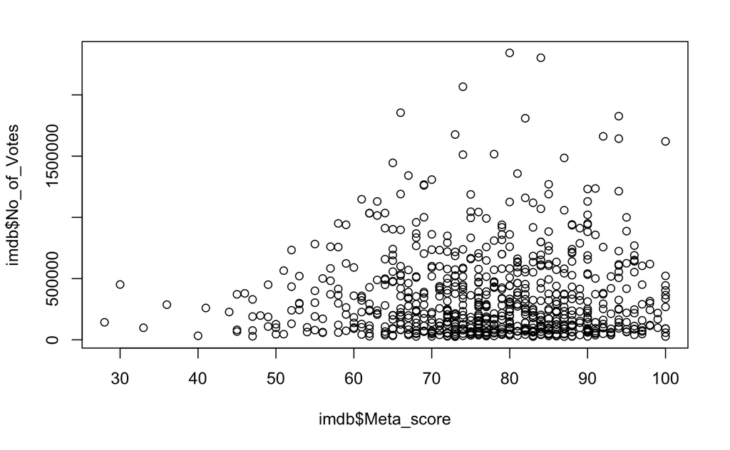

```r
view(imdb)
plot(imdb$Meta_score,imdb$No_of_Votes)
```

#Here we will create a new column to classify the rating of the movies as Low, Mid and High

```r
#ifelse(TEST, if TRUE, if FALSE)
imdb$rating <- as.factor(
  ifelse(imdb$Meta_score <= 50,"Low",
         ifelse(imdb$Meta_score <= 80, "Mid","High")))

#factor is a class, it means it is inside of a group

summary(imdb$rating)
```

```
High  Low  Mid
 299   22  393
```

#Now we will proceed to split the data

```r
set.seed(123)
sample <- sample.split(imdb$Meta_score, SplitRatio = .75)
train <- subset(imdb, sample == TRUE)
test <- subset(imdb, sample == FALSE)
```

#Here we will visualize the data to get a better understanding

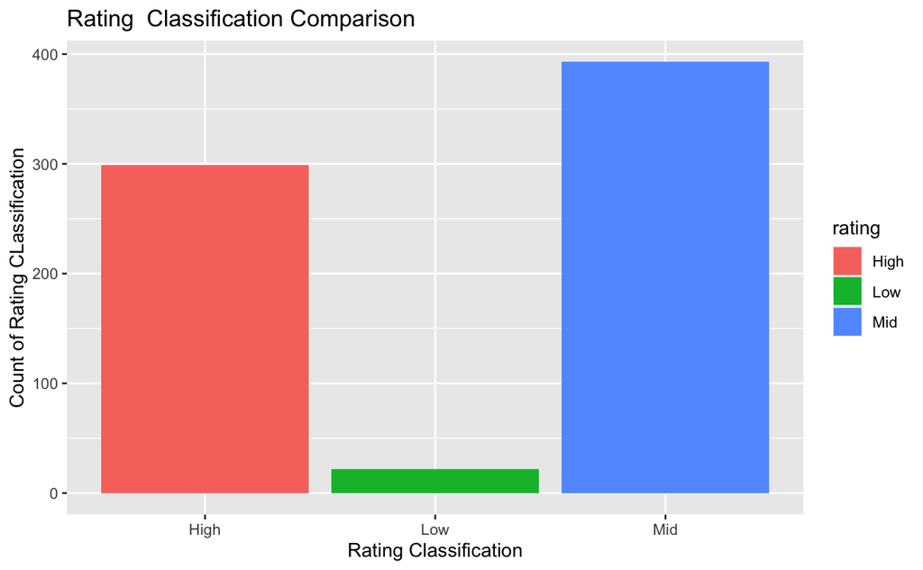

```r
ggplot(imdb, aes(rating)) + geom_bar(aes(fill=rating)) + labs(title = "Rating  Classification Comparison", x = "Rating Classification", y = "Count of Rating CLassification")
```

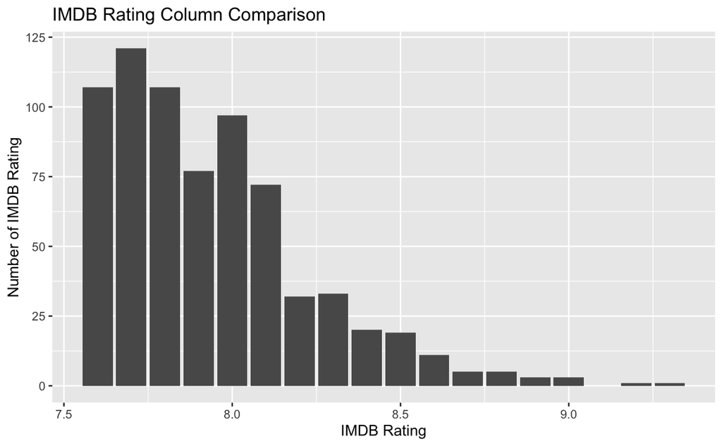

```r
ggplot(imdb, aes(IMDB_Rating)) + geom_bar(aes(fill=IMDB_Rating)) + labs(title = "IMDB Rating Column Comparison", x = "IMDB Rating", y = "Number of IMDB Rating")
```

#We now want to proceed to calculate KNN, or K-nearest neighbor, so we have to select two numeric predictors first. #I selected the columns Gross and No_of_Votes for the first predictors

```r
#only uses two predictors because it makes like a plot, x and y
Gross.No_of_Votes.train <- select(train,Gross,No_of_Votes)
Gross.No_of_Votes.test <- select(test,Gross,No_of_Votes)
```

#We now proceed to do KNN, because we already have our data split and already have a class (rating)

```r
predicted.Gross.No_of_Votes <- knn(train = Gross.No_of_Votes.train,
                                 test = Gross.No_of_Votes.test,
                                 cl =train$rating,
                                 k = 3)

#You could also type form as PredictedAlcoholDensity, for example
#K is 3 because we have 3 classs - low, mid and high
#KNN is classification
#cl = class - we do train instead of the actual data

predicted.Gross.No_of_Votes
```

```
  [1] Mid  High High High Mid  High High High High High Mid  Mid  High High High Mid  Mid  Mid  Mid  High Mid  High
 [23] Mid  Mid  High High High Mid  Low  High Mid  Mid  Mid  Mid  Mid  High Mid  High High Mid  Mid  High High Low
 [45] High Mid  High Mid  Mid  Mid  Mid  High High High High Mid  High Mid  High Mid  Mid  High Mid  Mid  High Mid
 [67] Mid  High High High Mid  High Mid  Mid  Mid  High Mid  High High Mid  Mid  High Mid  Mid  High High High High
 [89] High Mid  Mid  Mid  Mid  Mid  Mid  High Mid  Mid  Mid  Mid  Mid  High High Mid  Mid  Mid  Low  Mid  High High
[111] Mid  Low  Mid  Mid  High Mid  High Mid  High High Mid  High Mid  High Mid  Mid  Mid  High Mid  High Mid  High
[133] Mid  High Mid  Mid  High High High Mid  Mid  Mid  High Mid  High Mid  Mid  Mid  High Mid  Mid  Mid  High High
[155] Mid  Mid  High High Mid  Mid  Mid  High Mid  High Mid  Mid  High High High Mid  High High Mid  High Low  Mid
[177] High Mid
Levels: High Low Mid
```

#Confusion Matrix

```r
Gross.No_of_Votes.confusion <- table(predicted.Gross.No_of_Votes,test$rating)
Gross.No_of_Votes.confusion
```

```
predicted.Gross.No_of_Votes High Low Mid
                       High   32   3  44
                       Low     2   0   3
                       Mid    41   1  52
```

#We proceed to perform Accurace for our model - we want to know how accurate it is

```r
#Accuracy formula for confusion matrix
accuracyimdb <- sum(diag(Gross.No_of_Votes.confusion)) / sum(Gross.No_of_Votes.confusion)
cat("IMDB Confusion Accuracy is:",accuracyimdb)
```

```
IMDB Confusion Accuracy is: 0.4719101
```

#Since the accuracy for the previous KNN was not high, now we’ll repeat all previous steps for KNN, but this time we’ll try with Released Year and Run Time Min

```r
Released_Year.Runtime..min..train <- select(train,Released_Year,Runtime..min.)
Released_Year.Runtime..min..test <- select(test,Released_Year,Runtime..min.)
```

```r
predicted.Released_Year.Runtime..min. <- knn(train = Released_Year.Runtime..min..train,
                                 test = Released_Year.Runtime..min..test,
                                 cl =train$rating,
                                 k = 3)
predicted.Released_Year.Runtime..min.
```

```
  [1] High Mid  Mid  Mid  High Mid  Mid  Mid  High Mid  High High Mid  High Mid  Mid  High High Mid  Mid  High High
 [23] High High High High Mid  Mid  Mid  High High Mid  Mid  Mid  High Mid  High High Mid  Mid  Mid  High Mid  Mid
 [45] High Mid  Mid  Mid  Mid  Mid  Mid  Mid  Mid  High High High High High High High Mid  Mid  Mid  Mid  High Mid
 [67] Mid  Mid  Mid  Mid  Mid  High Mid  Mid  High High High High High High Mid  High Mid  Mid  Mid  Mid  Mid  Mid
 [89] Low  Mid  Mid  Mid  High Mid  Mid  Mid  Mid  High High Low  Mid  High High Mid  High High Low  Mid  Mid  Mid
[111] Mid  High High Mid  Mid  High Mid  High Mid  Mid  Mid  Mid  High Mid  Mid  Mid  Mid  Mid  High Mid  High High
[133] High Mid  Mid  Mid  High Mid  Low  High Mid  High Mid  High High Mid  Mid  Mid  High Mid  Mid  Mid  High High
[155] Mid  High High High High High Mid  Mid  High High Mid  Mid  Mid  High Mid  Mid  Mid  Mid  Mid  High High Mid
[177] Mid  Mid
Levels: High Low Mid
```

```r
Released_Year.Runtime..min..confusion <- table(predicted.Released_Year.Runtime..min.,test$rating)
Released_Year.Runtime..min..confusion
```

```
predicted.Released_Year.Runtime..min. High Low Mid
                                 High   39   0  32
                                 Low     3   0   1
                                 Mid    33   4  66
```

```r
accuracyimdb1 <- sum(diag(Released_Year.Runtime..min..confusion)) / sum(Released_Year.Runtime..min..confusion)
cat("IMDB Confusion Accuracy is:",accuracyimdb1)
```

```
IMDB Confusion Accuracy is: 0.5898876
```

#Since the accuracy for the previous 2 KNN was not high, now we’ll repeat all previous steps for KNN, but this time we’ll try with IMDB_Rating and No_of_Votes

```r
IMDB_Rating.No_of_Votes.train <- select(train,IMDB_Rating,No_of_Votes)
IMDB_Rating.No_of_Votes.test <- select(test,IMDB_Rating,No_of_Votes)
```

```r
predicted.IMDB_Rating.No_of_Votes <- knn(train = IMDB_Rating.No_of_Votes.train,
                                 test = IMDB_Rating.No_of_Votes.test,
                                 cl =train$rating,
                                 k = 3)
predicted.IMDB_Rating.No_of_Votes
```

```
  [1] High High High Mid  High Mid  Mid  High High High Mid  Mid  High Mid  Mid  Mid  High Mid  High Mid  Mid  Mid
 [23] Mid  High Mid  Low  Mid  High High Mid  Mid  Low  Mid  Mid  Mid  High High Mid  High High Mid  High Mid  Mid
 [45] Mid  Mid  Mid  Mid  High Mid  Mid  Mid  High Mid  Mid  High Mid  Mid  Mid  High Mid  High Low  Mid  Mid  High
 [67] Mid  Mid  Mid  High Mid  Mid  High Mid  High High Mid  Mid  High Mid  Mid  High High High Mid  Mid  Mid  Mid
 [89] Mid  High Mid  High High Mid  Mid  Mid  Mid  High High Mid  High Mid  High Mid  Mid  Low  High Mid  Mid  Mid
[111] High Mid  Mid  Mid  Mid  Mid  Mid  High High High Mid  Mid  Mid  Mid  High Mid  Mid  Mid  Mid  High Mid  High
[133] Mid  Mid  Mid  Mid  Mid  Mid  High High Mid  Mid  Mid  Mid  Mid  Mid  Mid  Mid  High Mid  Mid  High Mid  High
[155] Mid  Mid  Low  Mid  Mid  Mid  Mid  High Mid  Mid  Low  High Mid  Mid  High Mid  Mid  Mid  Mid  Mid  Mid  Mid
[177] Mid  Mid
Levels: High Low Mid
```

```r
IMDB_Rating.No_of_Votes.confusion <- table(predicted.IMDB_Rating.No_of_Votes,test$rating)
IMDB_Rating.No_of_Votes.confusion
```

```
predicted.IMDB_Rating.No_of_Votes High Low Mid
                             High   24   1  30
                             Low     4   0   2
                             Mid    47   3  67
```

```r
accuracyimdb2 <- sum(diag(IMDB_Rating.No_of_Votes.confusion)) / sum(IMDB_Rating.No_of_Votes.confusion)
cat("IMDB Confusion Accuracy is:",accuracyimdb2)
```

```
IMDB Confusion Accuracy is: 0.511236
```

#The accuracy for this KNN is still not high. Only 51%. Now we will proceed to visualize the findings.

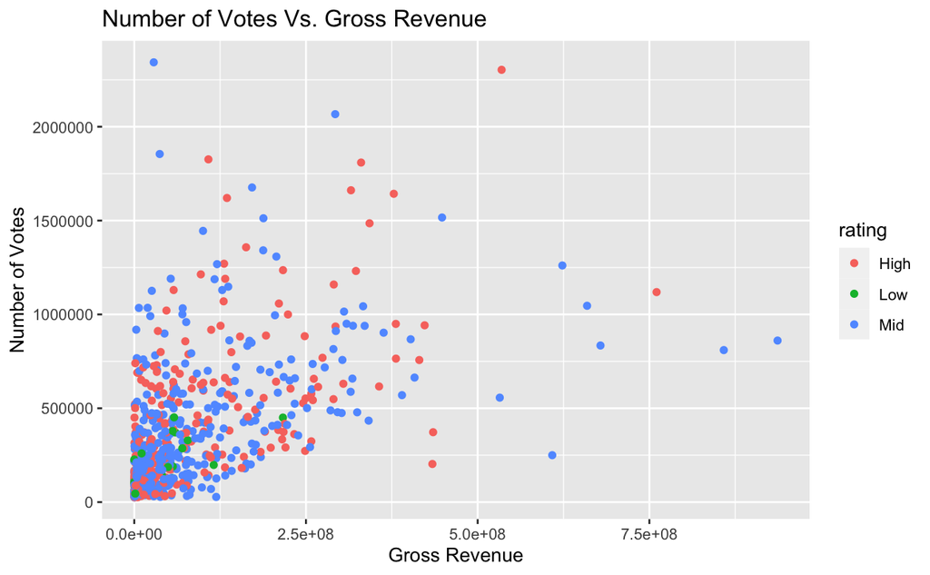

```r
ggplot(data = imdb, mapping = aes(x = Gross, y = No_of_Votes, color = rating)) + geom_point() + labs(title = "Number of Votes Vs. Gross Revenue", x = "Gross Revenue", y = "Number of Votes")
```

#From the graph above, we could say that there is a positive relation between the number of votes a movie got (popularity) and its gross revenue.

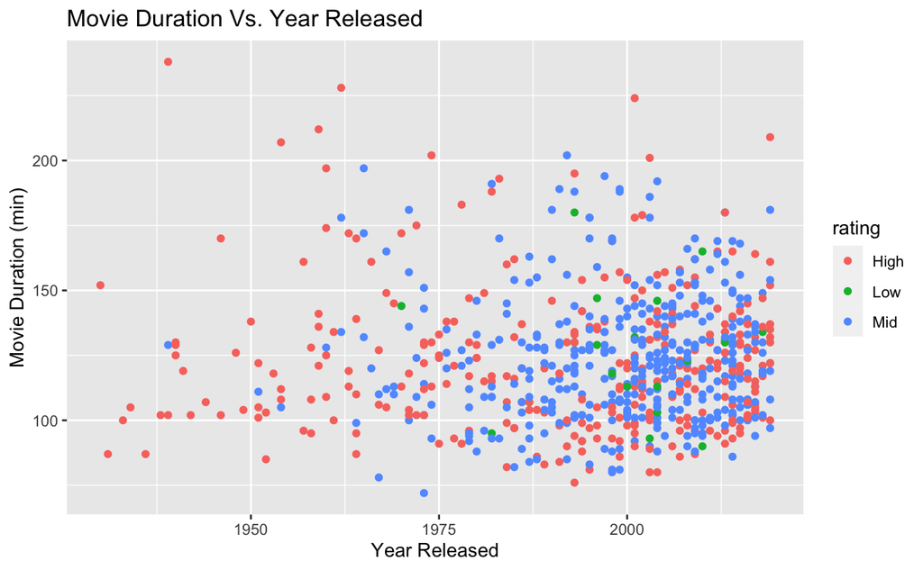

```r
ggplot(data = imdb, mapping = aes(x = Released_Year, y = Runtime..min., color = rating)) + geom_point() + labs(title = "Movie Duration Vs. Year Released", x = "Year Released", y = "Movie Duration (min)")
```

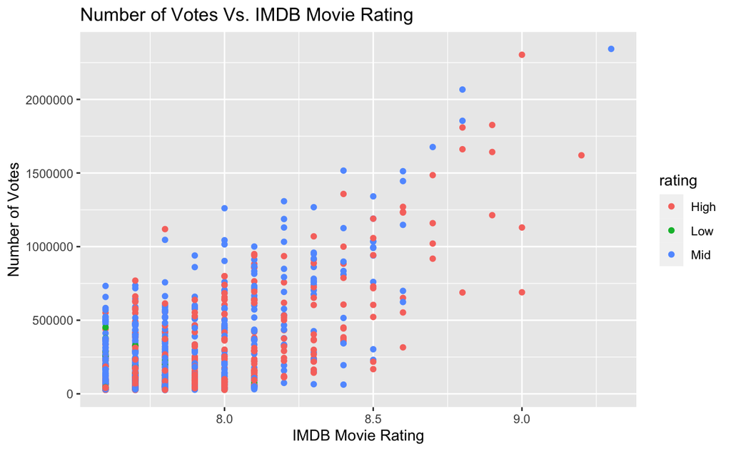

```r
ggplot(data = imdb, mapping = aes(x = IMDB_Rating, y = No_of_Votes, color = rating)) + geom_point() + labs(title = "Number of Votes Vs. IMDB Movie Rating", x = "IMDB Movie Rating", y = "Number of Votes")
```

#Since we have performed a model (KNN) we will now proceed to perform a second model (Stepwise regression) - for that, we will start with a linear model

```r
#Multivariate Linear Regression
#it's as regression with multiple variables

lmModel <- lm(Meta_score ~ IMDB_Rating + No_of_Votes + Gross + Runtime..min. + Released_Year, data = train)
lmPrediction <- predict(lmModel, test)
cat("Linear Regression RMSE:", rmse(lmPrediction,test$Meta_score))
```

```
Linear Regression RMSE: 10.82127
```

#We can see that the RMSE is high: 10.8217

#Now we proceed to get the stepwise forward model details

```r
stepwiseModel <- ols_step_forward_p(lmModel, details = TRUE)
```

```
Forward Selection Method
---------------------------

Candidate Terms:

1. IMDB_Rating
2. No_of_Votes
3. Gross
4. Runtime..min.
5. Released_Year

We are selecting variables based on p value...


Forward Selection: Step 1

+ IMDB_Rating

                         Model Summary
---------------------------------------------------------------
R                       0.294       RMSE                12.070
R-Squared               0.086       Coef. Var           15.675
Adj. R-Squared          0.085       MSE                145.688
Pred R-Squared          0.080       MAE                  9.465
---------------------------------------------------------------
 RMSE: Root Mean Square Error
 MSE: Mean Square Error
 MAE: Mean Absolute Error

                                ANOVA
----------------------------------------------------------------------
                 Sum of
                Squares         DF    Mean Square      F         Sig.
----------------------------------------------------------------------
Regression     7366.543          1       7366.543    50.564    0.0000
Residual      77797.457        534        145.688
Total         85164.000        535
----------------------------------------------------------------------

                                   Parameter Estimates
```

[output cut: 189 more lines]

```
Residual      72147.083        530        136.127
Total         85164.000        535
----------------------------------------------------------------------

                                     Parameter Estimates
---------------------------------------------------------------------------------------------
        model       Beta    Std. Error    Std. Beta      t        Sig       lower      upper
---------------------------------------------------------------------------------------------
  (Intercept)    243.822        69.621                  3.502    0.001    107.056    380.589
  IMDB_Rating     15.647         2.495        0.368     6.271    0.000     10.745     20.548
Released_Year     -0.144         0.031       -0.206    -4.705    0.000     -0.203     -0.084
  No_of_Votes      0.000         0.000       -0.176    -2.642    0.008      0.000      0.000
        Gross      0.000         0.000        0.115     2.282    0.023      0.000      0.000
Runtime..min.     -0.026         0.021       -0.053    -1.256    0.210     -0.066      0.015
---------------------------------------------------------------------------------------------
```

```r
stepwiseModel
```

```
                               Selection Summary
--------------------------------------------------------------------------------
        Variable                       Adj.
Step       Entered       R-Square    R-Square     C(p)         AIC        RMSE
--------------------------------------------------------------------------------
   1    IMDB_Rating        0.0865      0.0848    39.5082    4195.1653    12.0701
   2    Released_Year      0.1382      0.1349     9.1919    4165.9661    11.7349
   3    No_of_Votes        0.1429      0.1381     8.1927    4164.9764    11.7132
   4    Gross              0.1503      0.1439     5.5767    4162.3420    11.6737
   5    Runtime..min.      0.1528      0.1449     6.0000    4162.7499    11.6673
--------------------------------------------------------------------------------
```

#Now we proceed to get the stepwise backward model details

```r
stepwiseModel<- ols_step_backward_p(lmModel, details = TRUE)
```

```
Backward Elimination Method
---------------------------

Candidate Terms:

1 . IMDB_Rating
2 . No_of_Votes
3 . Gross
4 . Runtime..min.
5 . Released_Year

We are eliminating variables based on p value...


No more variables satisfy the condition of p value = 0.3


Variables Removed:



Final Model Output
------------------

                         Model Summary
---------------------------------------------------------------
R                       0.391       RMSE                11.667
R-Squared               0.153       Coef. Var           15.152
Adj. R-Squared          0.145       MSE                136.127
Pred R-Squared          0.135       MAE                  9.109
---------------------------------------------------------------
 RMSE: Root Mean Square Error
 MSE: Mean Square Error
 MAE: Mean Absolute Error

                                ANOVA
----------------------------------------------------------------------
                 Sum of
                Squares         DF    Mean Square      F         Sig.
----------------------------------------------------------------------
Regression    13016.917          5       2603.383    19.125    0.0000
Residual      72147.083        530        136.127
Total         85164.000        535
----------------------------------------------------------------------

                                     Parameter Estimates
---------------------------------------------------------------------------------------------
        model       Beta    Std. Error    Std. Beta      t        Sig       lower      upper
---------------------------------------------------------------------------------------------
  (Intercept)    243.822        69.621                  3.502    0.001    107.056    380.589
  IMDB_Rating     15.647         2.495        0.368     6.271    0.000     10.745     20.548
  No_of_Votes      0.000         0.000       -0.176    -2.642    0.008      0.000      0.000
        Gross      0.000         0.000        0.115     2.282    0.023      0.000      0.000
Runtime..min.     -0.026         0.021       -0.053    -1.256    0.210     -0.066      0.015
Released_Year     -0.144         0.031       -0.206    -4.705    0.000     -0.203     -0.084
---------------------------------------------------------------------------------------------
```

```r
stepwiseModel
```

```
[1] "No variables have been removed from the model."
```

#Now we proceed to get each error metrics for each stepwise model

```r
stepwiseModel <- ols_step_forward_p(lmModel, details = FALSE)
stepwisePrediction <- predict(stepwiseModel$model,test)
cat("Stepwise Foward RMSE:", rmse(stepwisePrediction,test$Meta_score), "\n")
```

```
Stepwise Foward RMSE: 10.82127
```

```r
stepwiseModel <- ols_step_backward_p(lmModel, details = FALSE)
stepwisePrediction <- predict(stepwiseModel$model,test)
cat("Stepwise Backward RMSE:", rmse(stepwisePrediction,test$Meta_score), "\n")
```

```
Stepwise Backward RMSE: 10.82127
```

```r
stepwiseModel <- ols_step_both_p(lmModel, details = FALSE)
stepwisePrediction <- predict(stepwiseModel$model,test)
cat("Stepwise Both RMSE:", rmse(stepwisePrediction,test$Meta_score), "\n")
```

```
Stepwise Both RMSE: 10.92213
```

#We can see that all errors are similar and are high.